# ggplot2: Introduction to geoms

2016-02-05

# Introduction

This is the third post in the series **Elegant Data Visualization with ggplot2**. In the previous [post](https://rsquaredacademy.github.io/blog/post/ggplot2-quick-tour/), we learnt how to create plots using the `qplot()` function. In this post, we will create some of the most routinely used plots to explore data using the `geom_*` functions.

## Point

Let us say we want to visualize the relationship between two continuous variables. For example, as visitors browse more pages on a website, the time spent on the website also increases. We cannot say that more time spent on a website indicates more page visits as some of the visitors might have spent a lot of time on a couple of pages or might have been idle. Using the ecommerce data, we will look at the relationship between number of pages visited and time on site. Now the best way to represent this relationship is a scatter plot i.e. represent the data using points.

You can download the data from [here](https://github.com/rsquaredacademy/datasets/blob/master/web.csv) or import it directly using `read_csv()` from the readr package.

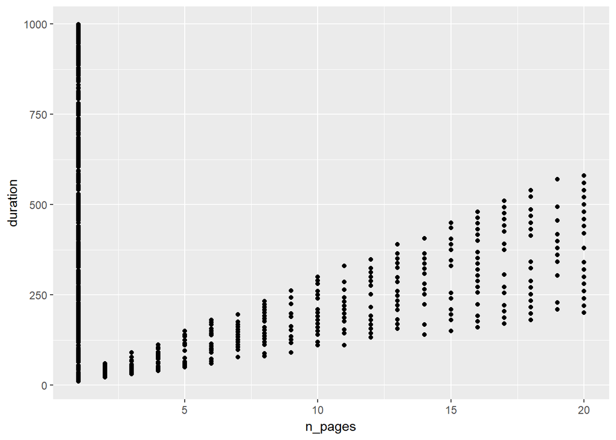

```r
ggplot(ecom, aes(x = n_pages, y = duration)) +
  geom_point()
```

We can fit a regression line or add horizontal or vertical lines to the plots using

- `geom_abline()`
- `geom_hline()`
- `geom_vline()`

You can add a vertical line using the `geom_vline()` function. The main argument of this function is `xintercept` which specifies the value on the X axis where the line must be drawn.

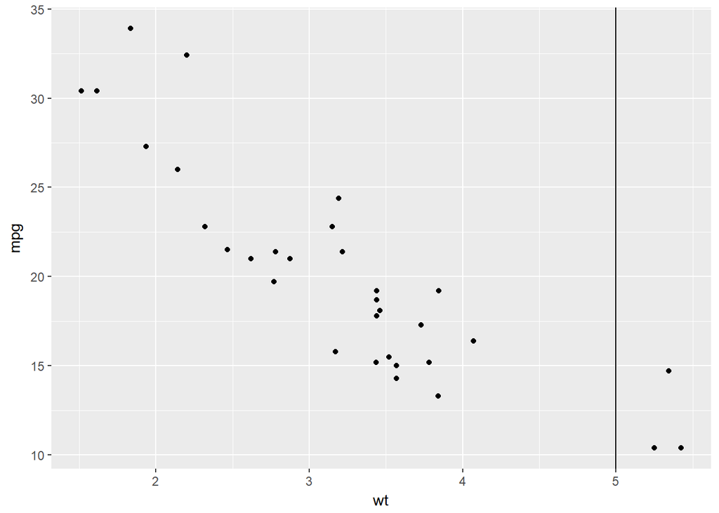

```r
ggplot(mtcars, aes(x = wt, y = mpg)) +
  geom_point() +
  geom_vline(xintercept = 5)
```

The `geom_hline()` function can be used to add a horizontal line.

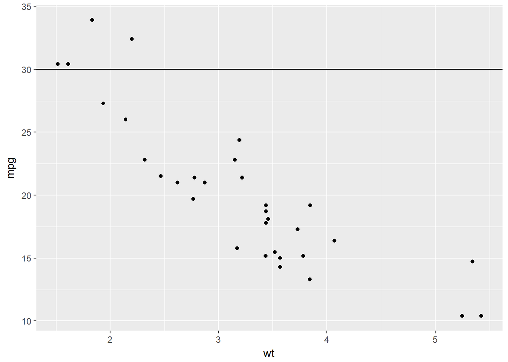

```r
ggplot(mtcars, aes(x = wt, y = mpg)) +
  geom_point() +
  geom_hline(yintercept = 30)
```

To fit a regression line to the plot, use the `geom_abline()` function. You need to specify values for the intercept and the slope.

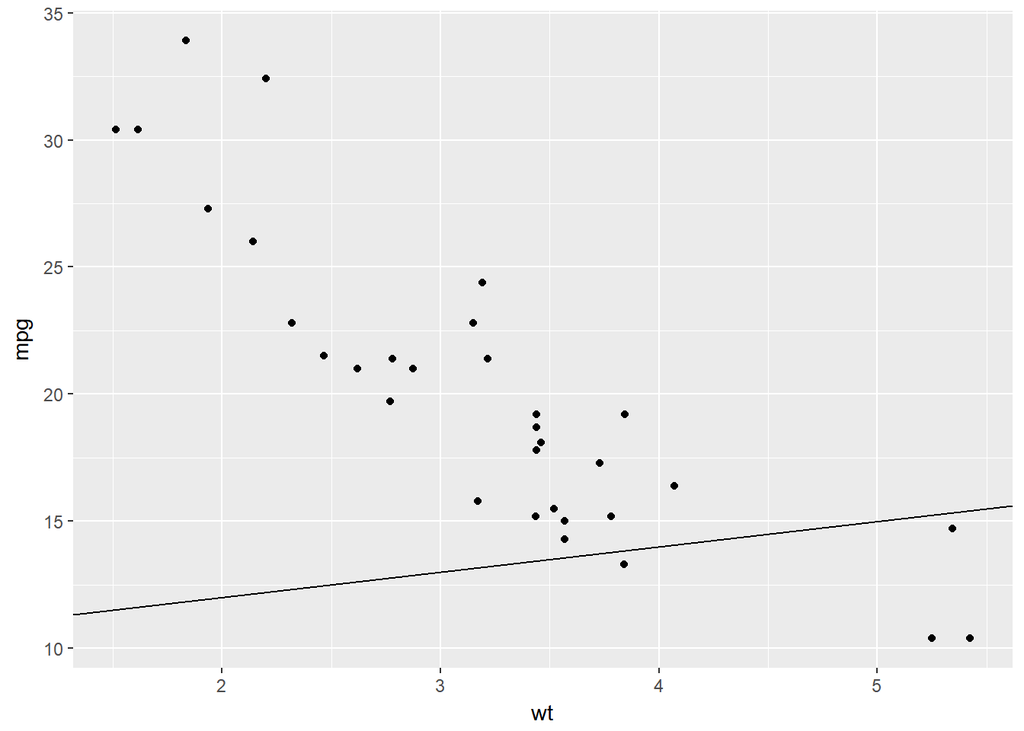

```r
ggplot(mtcars, aes(x = wt, y = mpg)) +
  geom_point() +
  geom_abline(intercept = 10, slope = 1)
```

Another way to fit a regression line to the plot is `geom_smooth()`. You need to specify the regression type using the `method` argument. You can choose to display the confidence intervals for the fitted values by setting the `se` argument to `TRUE` or `FALSE`.

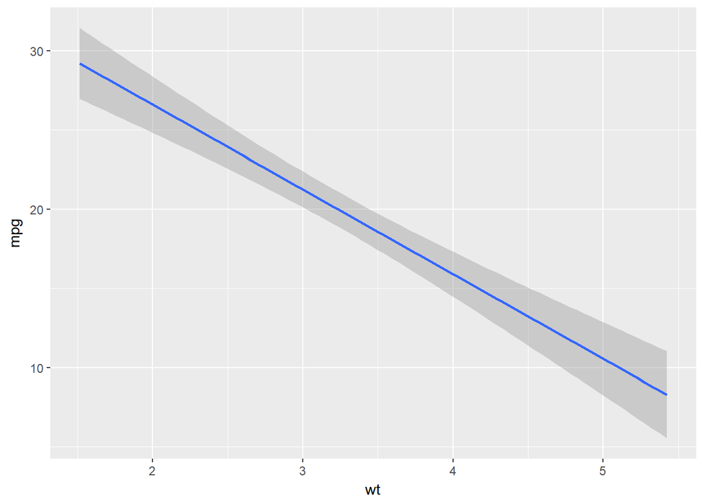

```r
ggplot(mtcars, aes(x = wt, y = mpg)) +
    geom_smooth(method = 'lm', se = TRUE)
```

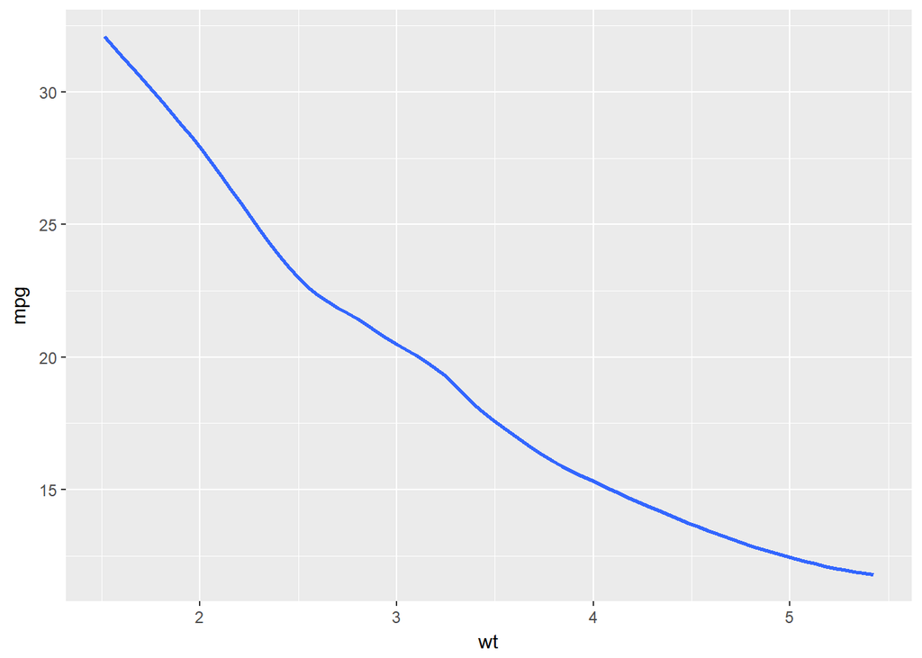

```r
ggplot(mtcars, aes(x = wt, y = mpg)) +
  geom_smooth(method = 'loess', se = FALSE)
```

We can modify the color, type and width of the lines but we will learn about them in the next [post.](https://rsquaredacademy.github.io/blog/post/ggplot2-introduction-to-aesthetics/)

## Bar

Continuing with our ecommerce website, let us say we want to know the distribution of the referrers or the devices. Such information is best displayed using bar plots. Use the `geom_bar()` function to create grouped/stacke bar plots.

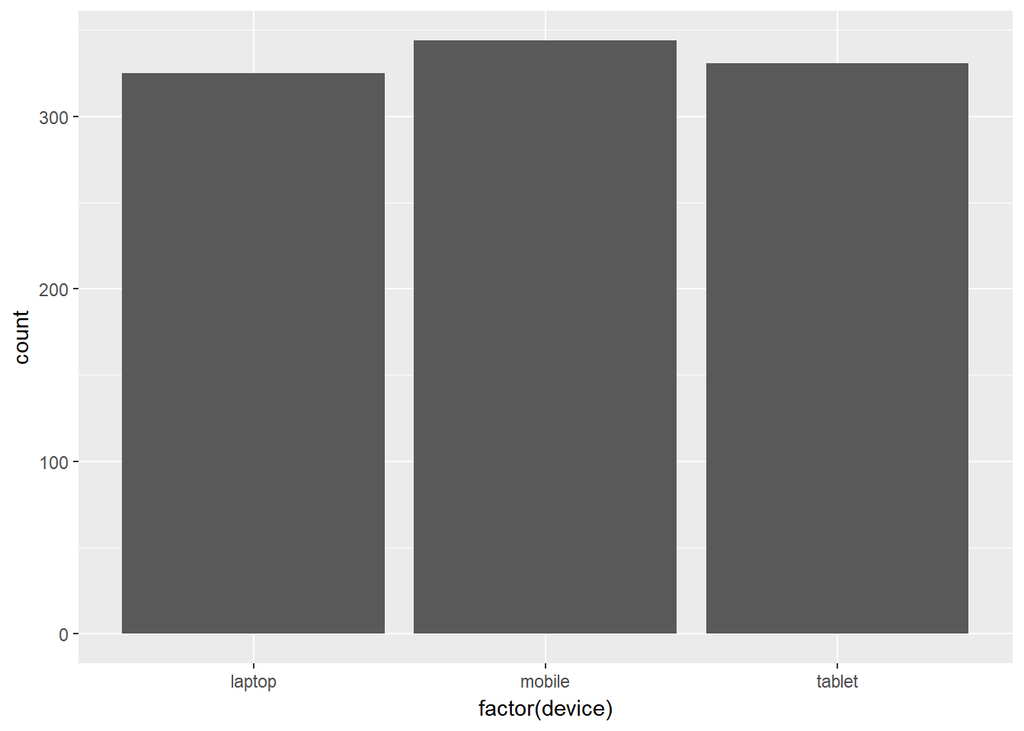

```r
ggplot(ecom, aes(x = factor(device))) +
  geom_bar()
```

Suppose you want to visualize the total revenue from different devices, you can map the variable to the Y axis.

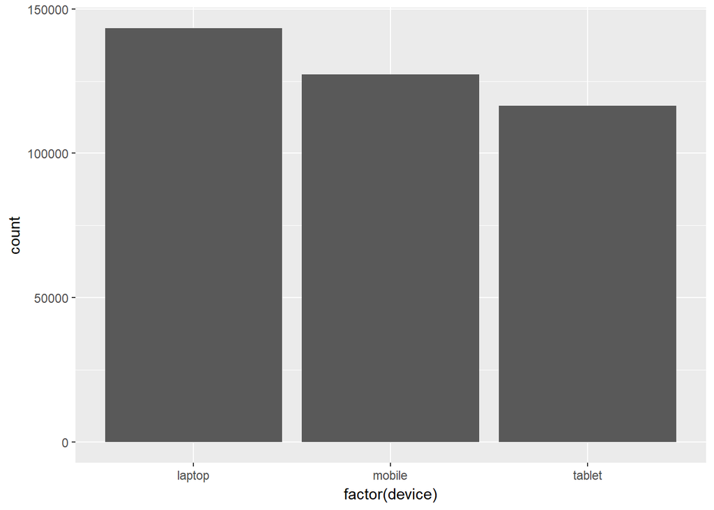

```r
ggplot(ecom, aes(x = factor(device))) +
  geom_bar(aes(weight = order_value))
```

If you want to get a breakdown of the purchasers/non-purchasers for different device types, create a stacked bar plot.

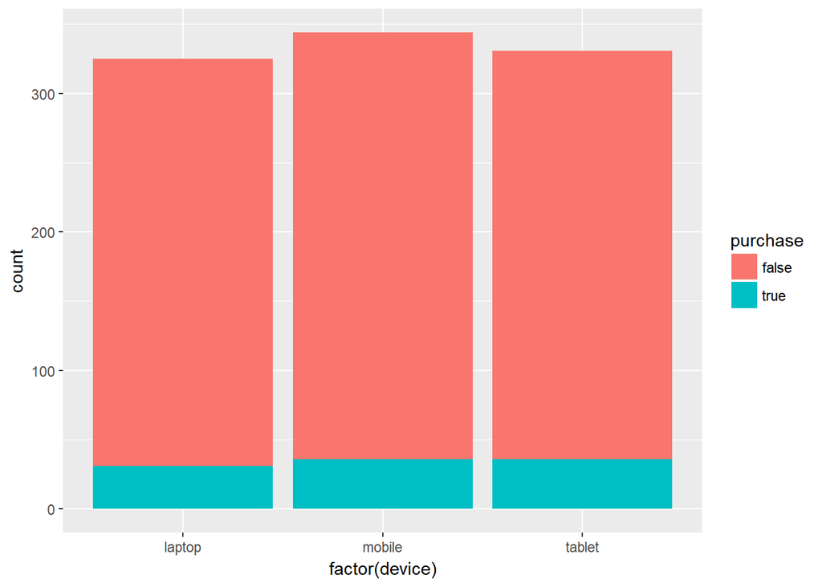

```r
ggplot(ecom, aes(x = factor(device))) +
  geom_bar(aes(fill = purchase))
```

To create horizontal bar plots, use the `coord_flip()` function. As the name indicates, it flips the X and Y coordinates.

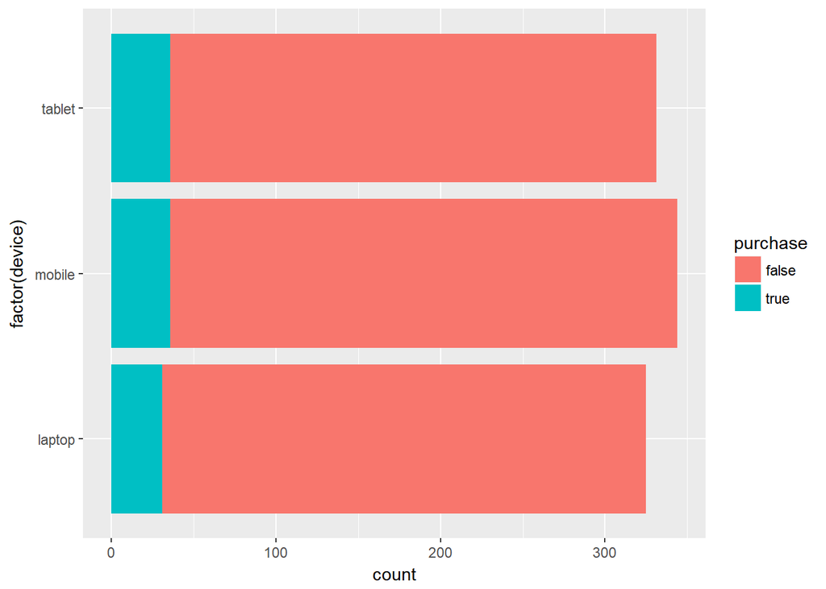

```r
ggplot(ecom, aes(x = factor(device))) +
  geom_bar(aes(fill = purchase)) +
  coord_flip()
```

Sometimes you have data in a tabular format. In such cases, you can use the `geom_col()` function.

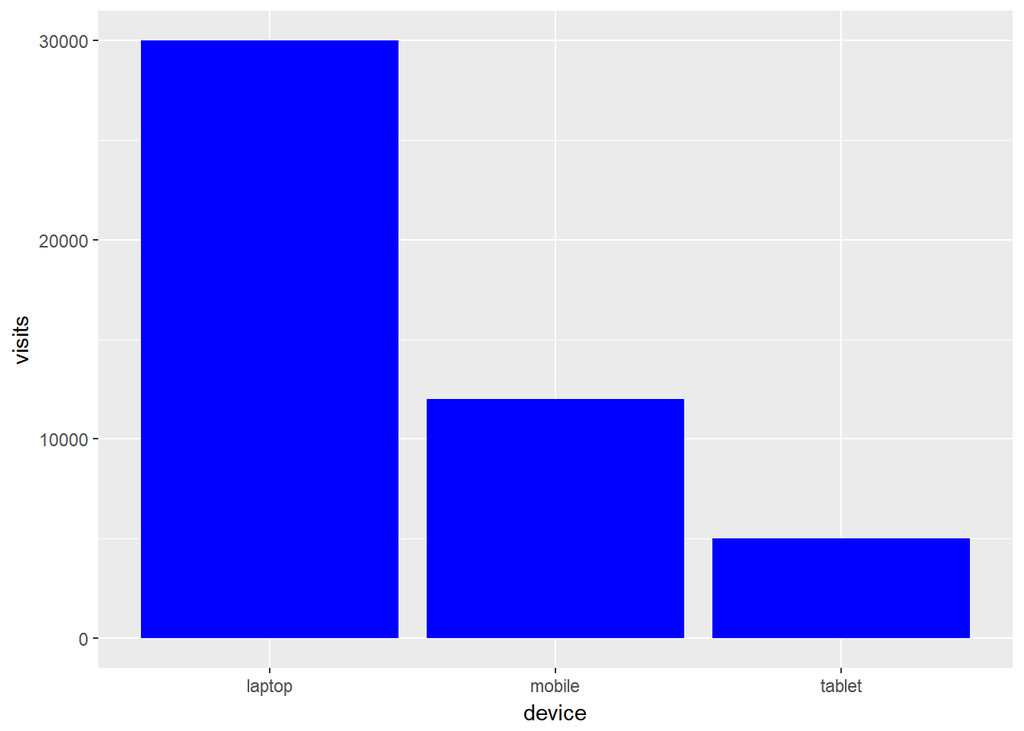

```r
device <- c('laptop', 'mobile', 'tablet')
visits <- c(30000, 12000, 5000)
traffic <- tibble::tibble(device, visits)
ggplot(traffic, aes(x = device, y = visits)) +
  geom_col(fill = 'blue')
```

## Boxplot

If you want to examine the distribution of a variable or detect outliers, boxplots are very handy. Let us look at the distribution of number of pages visited for different device types using the `geom_boxplot()` function.

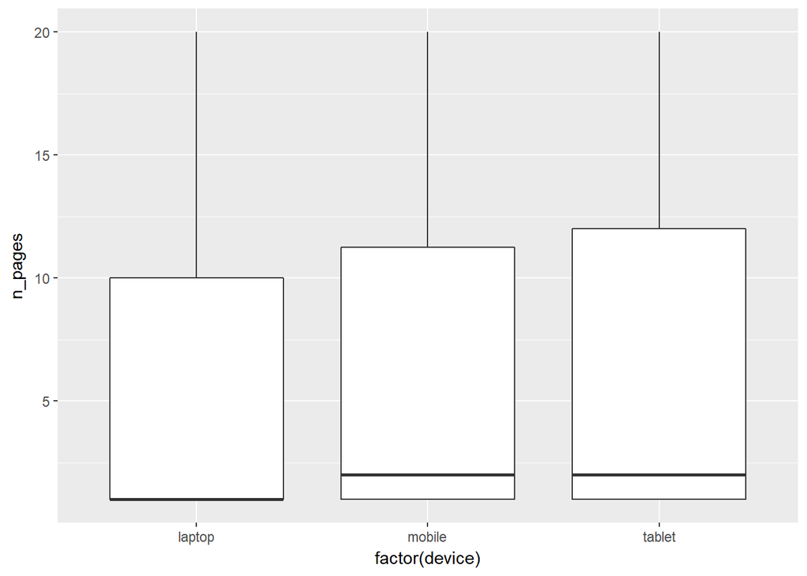

```r
ggplot(ecom, aes(x = factor(device), y = n_pages)) +
  geom_boxplot()
```

Use the `geom_jitter()` function to overlay the observations on the boxplot.

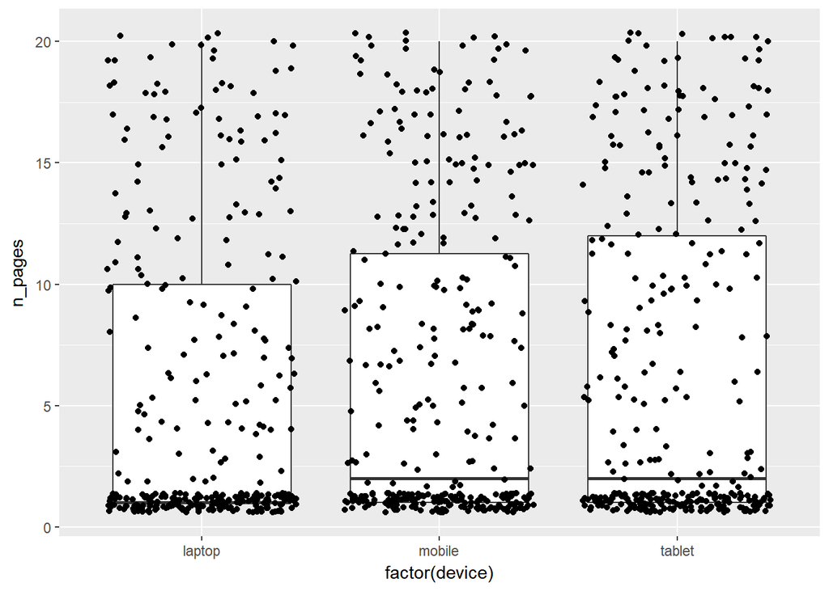

```r
ggplot(ecom, aes(x = factor(device), y = n_pages)) +
  geom_boxplot() +
  geom_jitter()
```

We will learn about modifying the appearance of the boxplot and the outliers in the next post.

## Histogram

Histograms are useful for examing the distribution of a continuous variable. Let us look at the distribution of time spent on the site using the `geom_histogram()` function and examine if it is skewed.

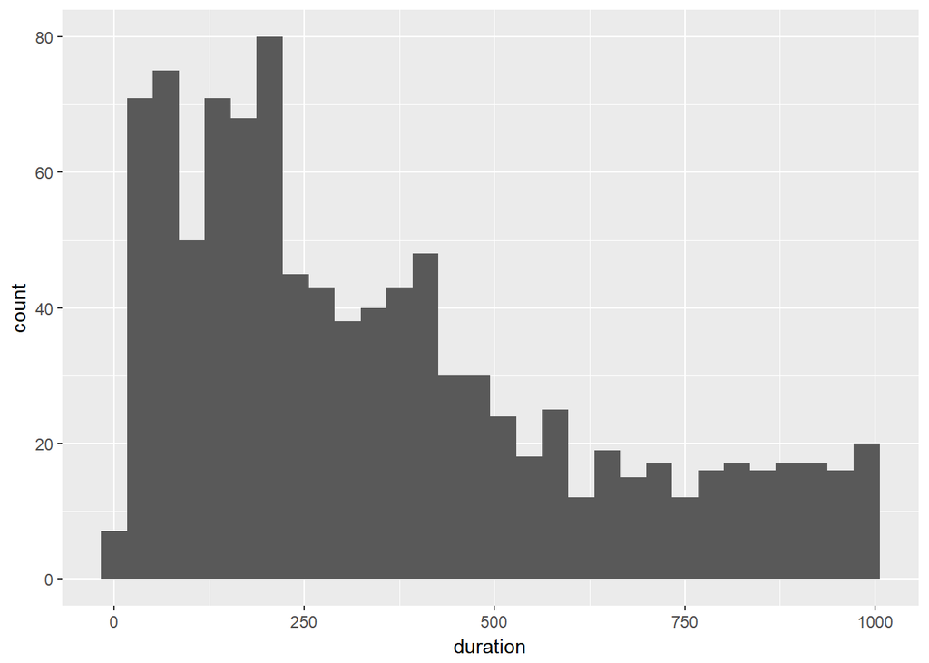

```r
ggplot(ecom, aes(x = duration)) +
  geom_histogram()
```

Specify the number of bins using the `bins` argument.

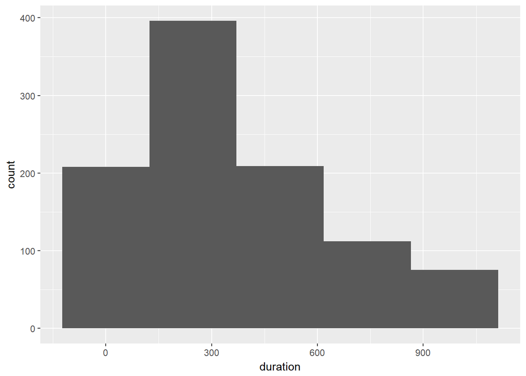

```r
ggplot(ecom, aes(x = duration)) +
  geom_histogram(bins = 5)
```

## Jitter

We used the `geom_jitter()` function to overlay observation on the boxplot.

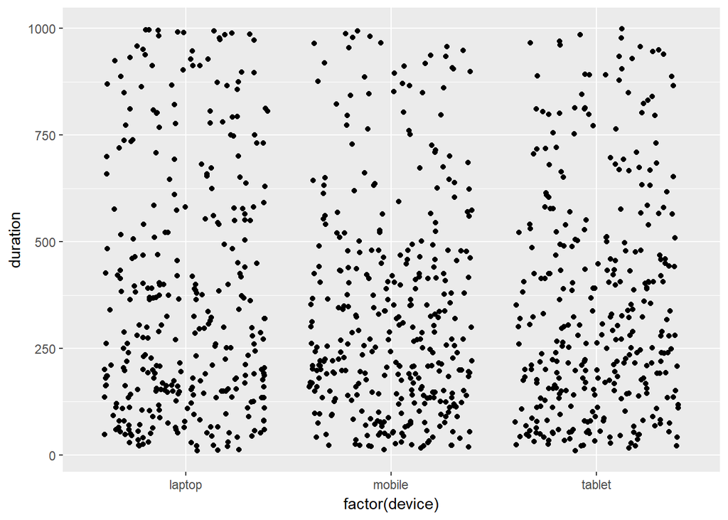

```r
ggplot(ecom, aes(x = factor(device), y = duration)) +
  geom_jitter()
```

Change the width and height to get a better overview.

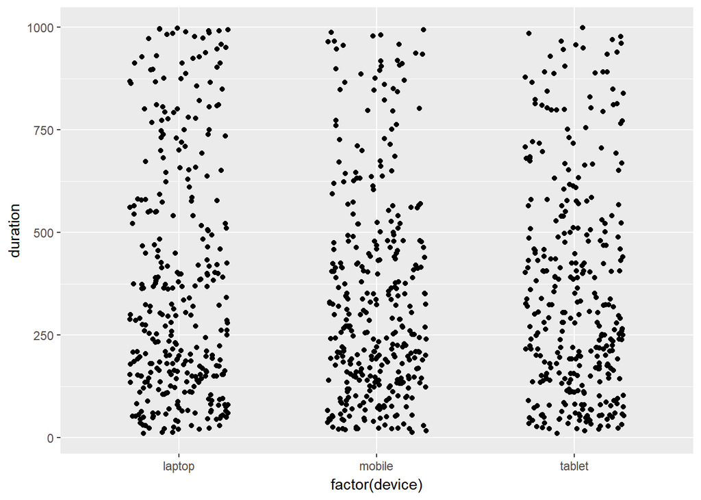

```r
ggplot(ecom, aes(x = factor(device), y = duration)) +
  geom_jitter(width = 0.25, height = 0.5)
```

## Label

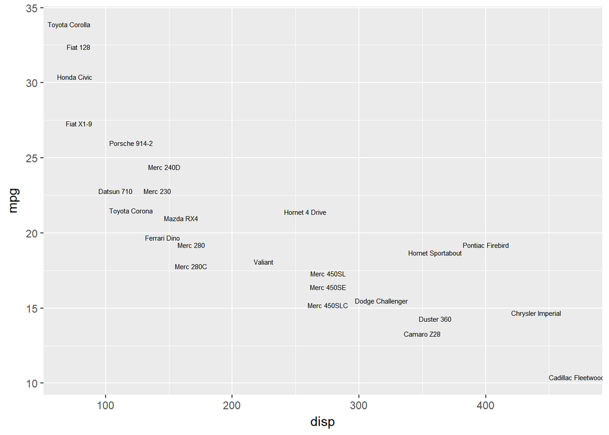

```r
ggplot(mtcars, aes(disp, mpg, label = rownames(mtcars))) +
  geom_text(check_overlap = TRUE, size = 2)
```

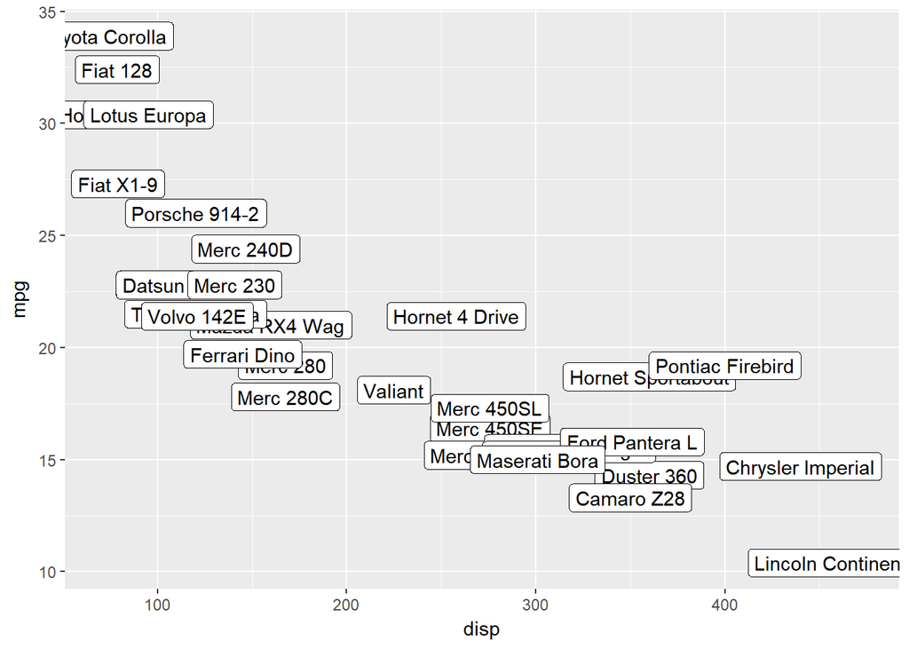

```r
ggplot(mtcars, aes(disp, mpg, label = rownames(mtcars))) +
  geom_label()
```

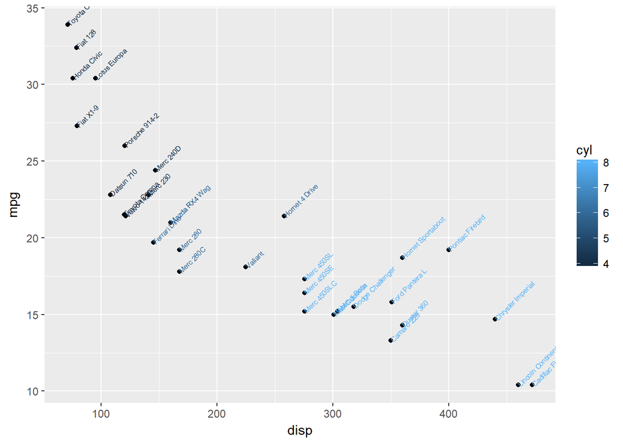

```r
ggplot(mtcars, aes(x = disp, y = mpg, label = rownames(mtcars))) +
  geom_point() +
  geom_text(aes(color = cyl), hjust = 0, nudge_x = 0.05,
            size = 2, angle = 45)
```

[output not shown]